# Deep_Learning_with_Pytorch_1_0_Creating_Our_Own_Dataset_From_Google_Images

## **Creating Our Own Dataset from Google Images**

OBJECTIVE - This project aims to create an image dataset through Google Images. We will have to repeat these steps for any new category we want to Google. Here I will create my own dataset and build a *Husky Vs Wolf Vs German Shepherd Classifier* and see how well it performs on the Validation set.

As I will be using *Google Colab* for the project, I ll have to mount my drive onto server in order to upload my url file which I ll be creating using some Javascript code and saving it to my local machine and then saving the url file as csv format.

To save files, we need to permit our Colaboratory instance to read and write files to our Google Drive. The following code does this for us.

```python
from google.colab import drive
drive.mount('/content/gdrive', force_remount=True)
root_dir = "/content/gdrive/My Drive/"
base_dir = root_dir + 'fastai-v3/'
```

They ensure that any edits to libraries, they are reloaded here automatically, and also that any charts or images displayed or shown in this notebook.

```python
%reload_ext autoreload
%autoreload 2
%matplotlib inline
```

Let's import our vision applications from the fastai library as well as our metrics.

```python
from fastai.vision import *
from fastai.metrics import error_rate
```

In Google Chrome we need to press `Ctrl``Shift``j` on Windows/Linux and `Cmd``Opt``j` on macOS, and a small window the javascript 'Console' will appear. In Firefox press `Ctrl``Shift``k` on Windows/Linux or `Cmd``Opt``k` on macOS. That is where we paste the JavaScript commands.

We will need to get the urls of each of the images. Before running the following commands, we may want to disable ad blocking extensions (uBlock, AdBlockPlus etc.) in Chrome. Otherwise the window.open() command doesn't work. Then we can run the following commands:

```
urls=Array.from(document.querySelectorAll('.rg_i')).map(el=> el.hasAttribute('data-src')?el.getAttribute('data-src'):el.getAttribute('data-iurl'));
window.open('data:text/csv;charset=utf-8,' + escape(urls.join('\n')));
```

### **Creating a directory and uploading URLs file into our server**

We choose appropriate names for labeled images. We have to run these steps multiple times to create different labels.

```python
folder = 'husky'
file = 'urls_husky.csv'
```

```python
folder = 'wolf'
file = 'urls_wolf.csv'
```

```python
folder = 'germanshepherd'
file = 'urls_germanshepherd.csv'
```

We will have to run this cell once per category. Here we are accessing our google drive as a file system using standard python commands to both read and write files. We are adding a base directory **base_dir** before path in our notebook.

```python
path = Path(base_dir + 'data/animals')
dest = path/folder
dest.mkdir(parents=True, exist_ok=True)
```

Fianlly, we have to load our urls. Let's check it.

```python
path.ls()
```

[output not shown]

### **Downloading Images**

Now we will download our images from the respective url files. You just have to specify the urls filename as well as the destination folder and this function will download and save all images that can be opened. If they have some problem in being opened, they will not be saved.

We can choose a maximum number of images to be downloaded. In this case we will not download all the urls.

We will need to run this line once for every category.

```python
classes = ['husky','wolf','germanshepherd']
```

```python
download_images(path/file, dest, max_pics=500)
```

Then, we can remove any images that can't be opened.

```python
for c in classes:
    print(c)
    verify_images(path/c, delete=True, max_size=500)
```

```
husky
```

```
wolf
```

```
germanshepherd
```

### **Viewing our Data**

```python
np.random.seed(17)
data = ImageDataBunch.from_folder(path, train='.', valid_pct=0.2, ds_tfms=get_transforms(), size=224, num_workers=4)
data.normalize(imagenet_stats)
```

```
ImageDataBunch;

Train: LabelList (768 items)
x: ImageList
Image (3, 224, 224),Image (3, 224, 224),Image (3, 224, 224),Image (3, 224, 224),Image (3, 224, 224)
y: CategoryList
husky,husky,husky,husky,husky
Path: /content/gdrive/My Drive/fastai-v3/data/animals;

Valid: LabelList (192 items)
x: ImageList
Image (3, 224, 224),Image (3, 224, 224),Image (3, 224, 224),Image (3, 224, 224),Image (3, 224, 224)
y: CategoryList
germanshepherd,germanshepherd,germanshepherd,husky,germanshepherd
Path: /content/gdrive/My Drive/fastai-v3/data/animals;

Test: None
```

```python
data.classes
```

```
['germanshepherd', 'husky', 'wolf']
```

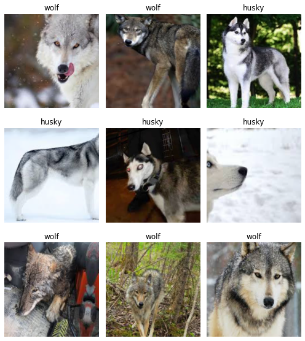

```python
data.show_batch(rows=3, figsize=(7,8))
```

```python
data.classes, data.c, len(data.train_ds), len(data.valid_ds)
```

```
(['germanshepherd', 'husky', 'wolf'], 3, 768, 192)
```

### **Training Resnet34**

```python
learn = cnn_learner(data, models.resnet34, metrics=error_rate)
```

```
Downloading: "https://download.pytorch.org/models/resnet34-333f7ec4.pth" to /root/.cache/torch/checkpoints/resnet34-333f7ec4.pth
```

```python
learn.lr_find()
```

77.78% [7/9 25:44<07:21]

| epoch | train_loss | valid_loss | error_rate | time |
| --- | --- | --- | --- | --- |
| 0 | 1.683022 | #na# | 03:38 |  |
| 1 | 1.648861 | #na# | 03:40 |  |
| 2 | 1.646650 | #na# | 03:42 |  |
| 3 | 1.373339 | #na# | 03:42 |  |
| 4 | 1.024008 | #na# | 03:43 |  |
| 5 | 0.817444 | #na# | 03:43 |  |
| 6 | 1.351786 | #na# | 03:34 |  |

25.00% [3/12 00:56<02:50 2.3504]

```
LR Finder is complete, type {learner_name}.recorder.plot() to see the graph.
```

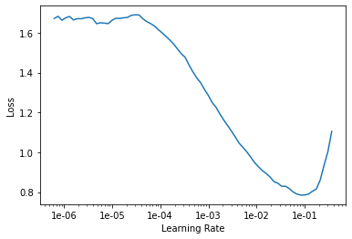

```python
learn.recorder.plot()
```

```python
learn.fit_one_cycle(4, max_lr=slice(3e-4,3e-2))
```

| epoch | train_loss | valid_loss | error_rate | time |
| --- | --- | --- | --- | --- |
| 0 | 0.447627 | 0.512765 | 0.057292 | 03:59 |
| 1 | 0.391395 | 0.706498 | 0.057292 | 03:54 |
| 2 | 0.342424 | 0.647898 | 0.057292 | 03:51 |
| 3 | 0.303773 | 0.571902 | 0.057292 | 04:01 |

We can see that our classifier has an accuracy of around *94.27%*. If we had used *resnet50*, our accuracy would have been increased too and yes, having more data would also work.

### **Interpretation**

```python
interp = ClassificationInterpretation.from_learner(learn)
```

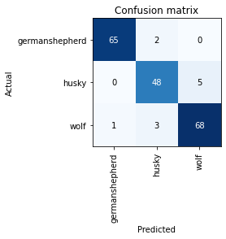

```python
interp.plot_confusion_matrix()
```

Let's export our model, and use it to make predictions. We can use our CPU to do this for us. Let's provide it with the image path to test results.

```python
learn.export()
```

```python
defaults.device = torch.device('cpu')
```

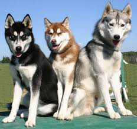

```python
img = open_image(path/'husky'/'00000017.jpg')
img
```

```python
learn = load_learner(path)
```

```python
pred_class, pred_idxs, outputs = learn.predict(img)
pred_class
```

```
Category husky
```

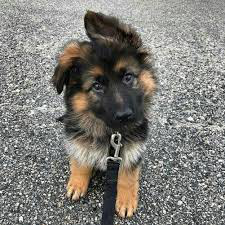

```python
img2 = open_image(path/'germanshepherd'/'00000018.jpg')
img2
```

```python
pred_class, pred_idxs, outputs = learn.predict(img2)
pred_class
```

```
Category germanshepherd
```

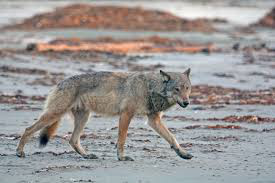

```python
img3 = open_image(path/'wolf'/'00000039.jpg')
img3
```

```python
pred_class, pred_idxs, outputs = learn.predict(img3)
pred_class
```

```
Category wolf
```

### **Our Classifier is working as we expected making right predictions on all three classes.**